# STA9750 HW2

# What does it mean to be a man?

## Q1

[interactive chart not shown]

[interactive chart not shown]

[interactive chart not shown]

[interactive chart not shown]

[interactive chart not shown]

It seems gay men feel there is greater unhealthy social pressure on them as opposed to their straight counterparts. Gay men also worry more about their physique and other physical attributes such as hair/hairline, height, weight, sexual performance, and appearance of genitalia as well as their mental health, and finances. The only thing straight men worry about more than gay men is their physical health and ability to provide for their family.

When it comes to work straight men are more so than gay men of the opinion that men make more money, have more professional opportunities, and have more choices, while gay men believe men are taken more seriously on a greater scale than straight men do as well as offered more praise. On the whole, straight men feel they are at a disadvantage in the workplace far more than gay men.

In the romantic realm straight men seem to try to always be the one who pays for a date far more than do gay men who are on the whole much more likely to sometimes or often be the one who pays.

As far as physical intimacy, gay men are more keen on verbal confirmation of consent while straight men are more likely to make a physical move to see how the other person reacts.

## Q2

[interactive chart not shown]

[interactive chart not shown]

[interactive chart not shown]

[interactive chart not shown]

[interactive chart not shown]

In breaking down our analysis by White versus Non-White we see similar trends emerging. Non-White men similar to Gay/Bisexual men feel that society puts unhealthy pressure on them more than White and Straight Men do.

Non-White men worry more than White men about finances as well as most physical characteristics except their weight and physical health.

Non-White men more so than White men sense that men are taken more seriously at work, that men have more choices, and that men get more support from their managers.

Both White and Non-White men alike feel that the disadvantage of being a man in the workplace is greater risk of being accused of sexual harassment.

When it comes to dating Non-White men are less likely to always pay for the date. And in terms of physical intimacy, Non-White men are more keen than their White counterparts on asking for verbal consent but are also more likely to make a physical move to see how the other person reacts as a way to gauge interest.

## Q3

[interactive chart not shown]

For one of the questions not mentioned in the article I decided to look at reasons men who said they pay Always or Often on a date engage in that behavior. It seems that there is consensus among All Men and White and Non-White men that ‘it’s the right thing to do’. Non-White men do seem to feel that there is a higher societal expectation on them to pay as often as they do. Non-White men also seem to pay as a test of whether the other person will offer to share the cost twice as often as White men do while White men are much more likely to pay because they make more money than their date.

The other point of interest is whether or not men think differently about their behavior at work in the wake of #MeToo. It seems White men are less acutely aware of their behavior at work in the wake of #MeToo than their Non-White counterparts while a total of 16% of all men surveyed have thought differently about their workplace behavior in the wake of #MeToo.

# Basketball League

## Q1

## Q2

## Q3

### a.

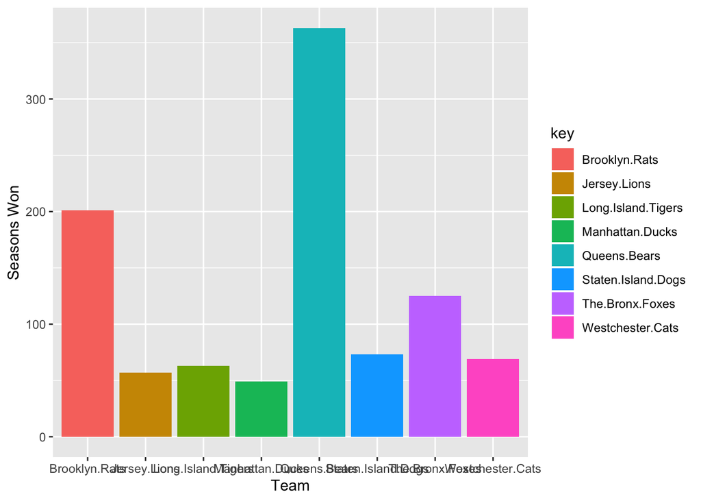

### b.

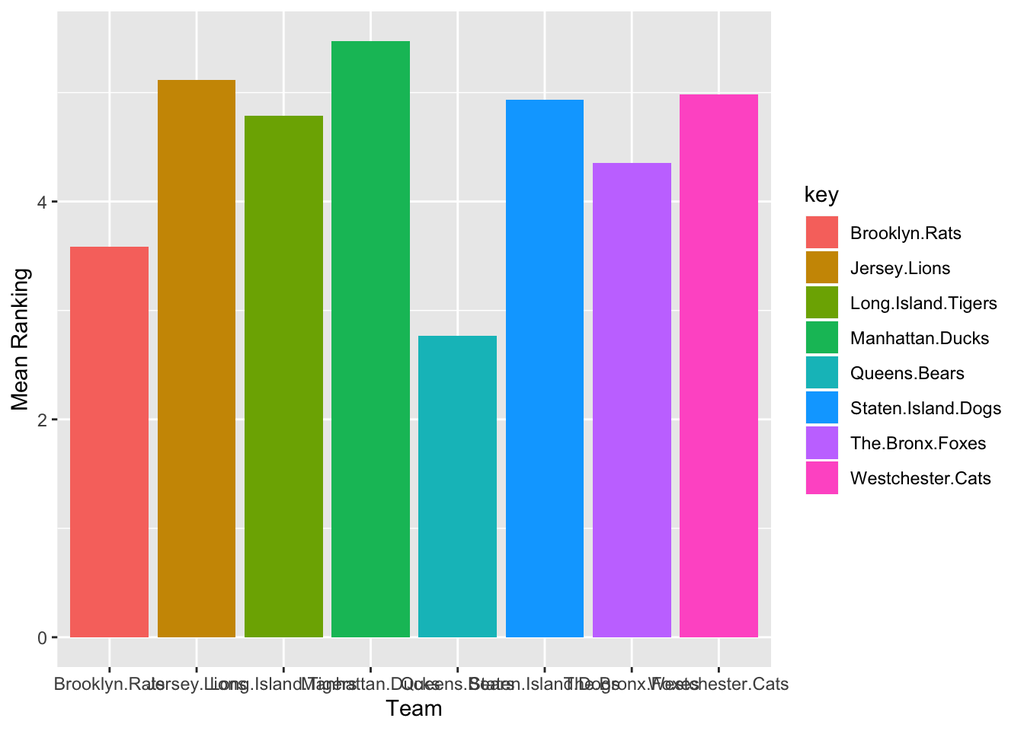

```r
league_sim %>% summarise_all(funs(mean)) %>% gather(key,value) %>% ggplot() + geom_col(aes(x=key,y=value,fill=key)) + ylab('Mean Ranking') + xlab('Team')
```

## **INCOMPLETE** Q4 I coded myself into a corner on this question and am quite lost. Sad.

```
## $p_spread
## [1] 5
##
## $winner
##                winner
## homename Jersey Lions
##
## $loser
##                     loser
## awayname Westchester Cats
```

# Restaurant

## Q1

Since weekday and weekend profit are both normally distributed and we know that the sum of two normally distributed variables (if they are independent) is also a normally distributed random variable, then we can sum up weekends and weekdays to obtain a weekly distribution of sales. Now the question is a bit confusing as to what constitutes a random variable here.

The sum of weekly expenses is 14000

Thus we are looking for the probability that the restaurant makes at least 14000 in revenue in any given week which is given by area under the distribution curve with a lower bound at 14000. Using pnorm produces the following result:

```r
(1-pnorm(14000,mean = 16000, sd = sqrt(8210000)))*100
```

```
## [1] 75.74129
```

We can see that there is a 76% chance that the restaurant makes a profit on any given week.

## Q2

```r
pnorm(62000,mean=71000,sd = sqrt(160690000))*100
```

```
## [1] 23.88573
```

Here we see that there is about a 24% chance that the restaurant doesn’t make money in December.

## Q3

Assuming for simplicity 52 weeks in a year and knowing already that the weekly distribution has a mean of 16000 we can find the annual mean to be 52*16000 = 832000 and the annual expenses to be 52*14000 = 728000, as such, annual expected profit is 832000-728000 = 104000.

## Q4

If the marketing campaign succeeds the annual profit will be 832000*1.15 - 728000 - 10000 = 218800

If the marketing campaign fails the annual profit will be 832000 - 728000 - 10000 = 94000